# Graphics in R

# Basic Plots

# Setup

Run the Setup.R file.

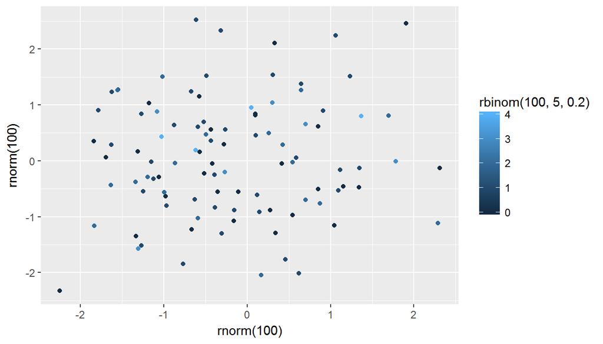

# ggplot2 In a Nutshell

- Package for statistical graphics
- Developed by Hadley Wickham
- Designed to adhere to good graphical practices
- Supports a wide variety plot types
- Constructs plots using the concept of layers
- http://had.co.nz/ggplot2/ or Hadley’s book *ggplot2: Elegant Graphics for Data Analysis}* for reference material

# qplot Function

### _Q_uick Plot

The `qplot()` function is the basic workhorse of ggplot2

- Produces all plot types available with ggplot2
- Allows for plotting options within the function statement
- Creates an object that can be saved
- Plot layers can be added to modify plot complexity

# qplot Structure

The `qplot()` function has a basic syntax:

*qplot(variables, plot type, dataset, options)*

- variables: list of variables used for the plot
- plot type: specified with a *geom =* statement
- dataset: specified with a *data =* statement
- options: there are so, so many options!

# Diamonds Data

Objective: Explore the diamonds data set (preloaded along with ggplot2) using `qplot` for basic plotting.

The data set was scraped from a diamond exchange company data base. It contains the prices and attributes of over 50,000 diamonds.

# Examining the Diamonds Data

What does the data look like?

Look at the top few rows of the diamond data frame to find out!

```r
head(diamonds)
```

```
## # A tibble: 6 × 10
##   carat       cut color clarity depth table price     x     y     z
##   <dbl>     <ord> <ord>   <ord> <dbl> <dbl> <int> <dbl> <dbl> <dbl>
## 1  0.23     Ideal     E     SI2  61.5    55   326  3.95  3.98  2.43
## 2  0.21   Premium     E     SI1  59.8    61   326  3.89  3.84  2.31
## 3  0.23      Good     E     VS1  56.9    65   327  4.05  4.07  2.31
## 4  0.29   Premium     I     VS2  62.4    58   334  4.20  4.23  2.63
## 5  0.31      Good     J     SI2  63.3    58   335  4.34  4.35  2.75
## 6  0.24 Very Good     J    VVS2  62.8    57   336  3.94  3.96  2.48
```

# Basic Scatterplot

Basic scatter plot of diamond price vs. carat weight

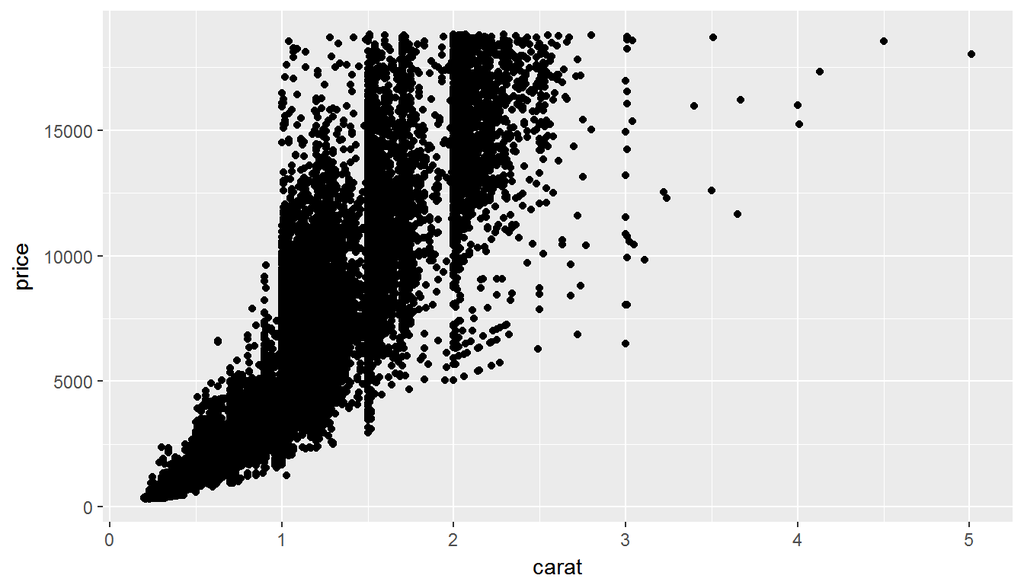

```r
qplot(carat, price, geom = "point", data = diamonds)
```

# Another Scatterplot

Scatter plot of diamond price vs carat weight showing versitility of options in `qplot`

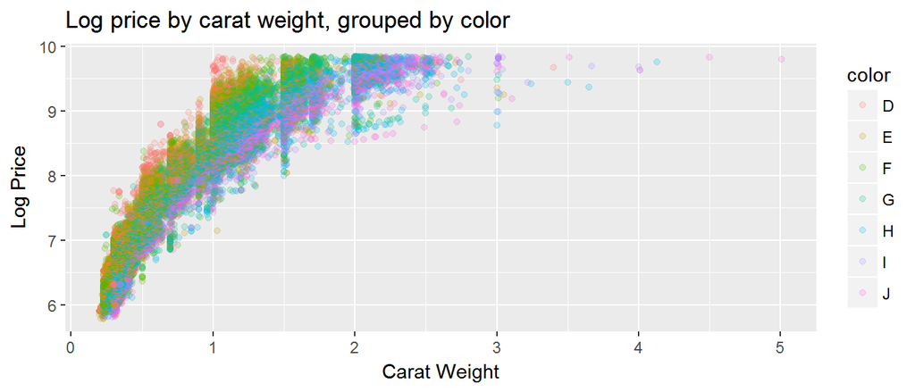

```r
qplot(carat, log(price), geom = "point", data = diamonds,
    alpha = I(0.2), colour = color,
    main = "Log price by carat weight, grouped by color") +
    xlab("Carat Weight") + ylab("Log Price")
```

# Your Turn

All of the your turns for this section will use the tips data set:

```r
tips <- read.csv("http://srvanderplas.github.io/NPPD-Analytics-Workshop/02.Graphics/data/tips.csv")
```

1. Use qplot to build a scatterplot of variables tips and total bill
2. Use options within qplot to color points by smokers
3. Clean up axis labels and add main plot title